# Red Personajes Enders Shadow

## Tarea de red de personajes

#### Jua$\eta$ Uri$\epsilon$l L$\epsilon$garia $\pi\epsilon$ña

### 0.- Descripción y resumen del libro que elegí

El libro que elegí se llama Ender's Shadow, una novela de ciencia ficción del autor Orson Scott Card.

Para que tenga mas sentido la discusión de resultados comenzaré esta tarea con un resumen de la novela. Este quizás se torne un poco extenso pero creo que es necesario para dar un mejor contexto al trabajo.

#### 0.1.- Primera parte del libro: calles de Rotterdam

La historia comienza con Bean, un niño vagabundo de tan solo 4 años que habita en las calles de Rotterdam. Bean posee una inteligencia extraordinaria, e invierte sus primeros dias en la calle observando la dinámica de los demás niños. Él se da cuenta de que los niños mas grandes (denóminados bullies) son los que acaparan siempre todas las raciones de comida en el comedor de beneficiencia, impidiendo, por fuerza e intimidación que esta llegue a los mas pequeños. Bean diseña un plan para imponer una nueva dinámica, bajo la cual niños mas pequeños como él puedan tener acceso a la comida. Para ello, en primer lugar se afilia con una de las bandas de niños pequeños, cuya lider es una niña llamada Poke. El plan se basa en someter a uno de los bullies mas debiles (esos que tienen que formarse hasta atrás en la fila del comedor), para formar una "familia" con este. Esta asociación cumpliría dos propósitos: en primer lugar los encargados del comedor, al ver que el bully traería consigo a niños pequeños, les darían preferencia de entrada; así mismo, y quizás mas importante, si alguno de los niños grandes llegasen a oponerse a que el bully ingresara con su familia, los niños pequeños podrían conformar una especie de mini ejercito y combatirlos junto con el bully.

Así es como Poke, decide que someterán a un bully cojo llamado Achilles. Los niños, comandados por Seargent, otro de los miembros de la banda, lo emboscan y tirán al suelo. Ahí es cuando Poke, sosteniendo una piedra, hace prometer a Achilles que cooperará con ellos. Bean a partir del poco diálogo que Poke sostiene con Achilles se da cuenta de que este último es demasiado inteligente y mas allá de ello, guarda un rencor de muerte hacia aquellos que lo humillan. Por esta razón le indica a Poke que Achilles no es el apropiado y debe matarlo. Poke sin embargo al ver la cooperación aparente de Achilles, hace caso omiso y lo deja vivir.

Al día siguiente Achilles llega con su nueva famila al comedor, y tras someter entre todos con brutalidad a Ulysses, uno de los bullies de la fila, los demás niños grandes se apartan y les permiten ingresar. Helga la encargada se muestra muy sorprendida y satisfecha de que por fin se está alimentando a los niños pequeños y no tarda en establecer una política que da prioridad a los bullies que traigan consigo una familia. Así, se establece una nueva dinámica donde varios bullies comienzan a formar estas asociaciones con niños pequeños, con el objetivo de conseguir comida.

En el mundo donde se desarrolla esta historia, la tierra ha sufrido previamente dos invasiones de una raza alienigena conocida como los insectores (buggers). Como medida de prevención ante un tercer ataque, las naciones de todo el mundo se unieron y crearon la flota internacional, cuyo complejo principal se encuentra en una estación espacial. Esta institución recluta a niños con aptitudes estratégicas sobresalientes, entrenandolos desde temprana edad para ser comandantes en el anticipado tercer ataque.

Dentro de las personas encargadas de reclutar en barrios de niños vagabundos se encuentra una monja llamada Sor Carlotta. Hasta el momento de esta historia, ella había tenido poco éxito, ya que la desnutrición presente en las calles hacia que fuera imposible que los niños desarrollaran la inteligencia necesaria para ingresar a la flota. Sin embargo, cuando Helga observa la nueva dinámica en el comedor, la llama de inmediato, pensando que el orquestador de este cambio era Achilles, y podría ser buen candidato para ingresar a la escuela de batalla.

Sor Carlotta, sin embargo, decide impartir clases y examinar a todos los miembros de la familia de Achilles. Bean, comodo con su nueva situación en el comedor, decide reprobar a propósito todas las pruebas, ya que ir al regimen militar de la estacíón espacial supondría un esfuerzo innecesario. Esto, hasta que una noche, Achilles lleva (con intenciones aparentemente románticas) a Poke hacia el rio de Rotterdam, y la ahoga en el mismo. Bean, quien tarda en llegar a la escena, observa desde lejos el asesinato, y se da cuenta de que él será el siguiente en morir si no se aleja de Achilles, ya que fue él quien dijo a Poke que lo asesinara cuando estaba en el suelo.

Bajo este nuevo propósito de escapar de Achilles, Bean comienza a obtener resultados nunca antes vistos en las pruebas cognitivas de la flota internacional, y no tardan en enviarlo a la estación espacial.

#### 0.2.- Segunda parte del libro: Escuela de batalla

Como contexto, los niños de la flota internacional deben pasar por varias etapas en su formación, empezando por la escuela de batalla y culminando con la escuela de comando. La escuela de batalla agrupa a los niños en diversos "ejercitos", cada uno con colores y simbolo diferentes, existen las escuadras salamandra, conejo, rata etc. Estos ejercitos se enfrentan regularmente en una sala que carece de gravedad, denominada sala de batalla. Las armas que se utilizan en estos enfrentamientos son pistolas que al disparar al traje del oponente paralizan la zona impactada. El objetivo es ir congelando a los oponentes para llegar a la puerta del enemigo y abrirla. La apertura de la puerta requiere un pequeño ritual donde 4 personas del equipo deben poner sus cascos en ella, a modo de llaves. Cabe resaltar que en esta sala hay varios objetos denominados estrellas, los cuales sirven para resguardarse y además pueden ser movidos. Así esencialmente esta escuela funciona con un sistema de Rankings donde los ejercitos van ganando puntos en los enfrentamientos en la sala de batalla.

Cuando Bean llega a la escuela de batalla decide investigar lo mas posible sobre esta. Gracias a su corta estatura logra infiltrarse en los ductos de aire y espiar las conversaciones de los comandantes Dimak (quien podemos considerar como el tutor de Bean) y Graff, encargado del estudiante promesa de la escuela: Ender Wiggin. Esto combinado con sus lecturas sobre estrategía le hacen descubrir algunas cosas:

1. Que estrategicamente, sobre todo en una batalla espacial esperar al oponente es inutil debido a las 3 dimensiones de movimiento que puede usar para atacarte. Es imposible defender la tierra y por lo tanto lo único que tiene sentido es atacar primero. Es así como se da cuenta de que no están entrenando a los niños para una posible tercera invasión de la tierra, sino que ellos comandarán remotamente naves enviadas hace años para invadir los planetas de los insectores. Esta idea también se refuerza por los modelos de naves viejas que usan los simuladores de la escuela. En palabras de Bean:

   > "The real problem is that unlike Vauban, we have only one strong point worth defending — Earth. And the enemy is not limited to a primary direction of approach. He could come from anywhere. From anywhere all at once. So we run into the classic problem of defense, cubed. The farther out you deploy your defenses, the more of them you have to have, and if your resources are limited, you soon have more fortifications than you can man. What good are bases on moons Jupiter or Saturn or Neptune, when the enemy doesn’t even have to come in on the plane of the ecliptic? He can bypass all our fortifications. The way Nimitz and MacArthur used two- dimensional island-hopping against the defense in depth of the Japanese in World War II. Only our enemy can work in three dimensions. Therefore we cannot possibly maintain defense in depth."

   > "There’s no point in trying to defend Earth at all. In fact, unless they have some defensive device we don’t know about, like some way of putting an invisible shield around a planet or something, the enemy is just as vulnerable. So the only strategy that makes any sense at all is an all-out attack. To send our fleet against *their* home world and destroy it."
2. Que las naves enviadas a atacar los planetas insectores estaban por llegar pronto, por lo cual el comandante Graff, tomaría medidas para entrentar al estudiante Ender rápido, para que pudiera comandarlas.

La primera acción que hacen para acelerar el entrenamiento de Ender es crear un ejercito especialmente para él: el ejercito dragón. Los comandantes Dimak y Graff, ya enterados de toda la información con la que contaba Bean, le piden que les de una alineación de los estudiantes que conformarán este ejercito. Bean, quien en sus exploraciones por los ductos de aire había anotado las contraseñas de varios oficiales, tenía acceso total a los perfiles de los estudiantes, y sabía que los alumnos que los profesores consideraban "mejores", sencillamente eran los que mejor encajaban en el sistema militar y llamaban la atención, mas no los mejor aptos e inteligentes. Así, se dispone a crear un nuevo ejercito de marginados, liderado por Ender, y con otros miembros importantes como Fly Molo, Crazy Tom, Vlad y Nikolai: el mejor amigo de Bean, que al final del libro descubre, es su hermano. Bean también se incluye a si mismo en dicho ejercito.

Los oficiales al notar la amplia superioridad del ejercito de Ender, comienzan a incrementar la frecuencia de batallas para el ejercito Dragón, a un punto en que Ender decide asignar a Bean una escuadra especial, dedicada a experimentar estrategias nuevas y creativas para seguir un paso adelante de la competencia. A pesar de que esto funciona por un tiempo, el cansancio y frustración de Ender crece debido al modo en que los profesores claramente ponen mas y mas presión sobre el. Esto llega a un punto de quiebre donde se asigna una batalla de la escuadra Dragón contra dos ejercitos al mismo tiempo. Ender, decidido a romper las reglas, tal y como hacen los profesores, decide probar una estrategía de Bean, la cual consiste en esencialmente congelar a muchos miembros del ejercito propio y disponer sus cuerpos de tal manera que formen una especie de nave, protegiendo unicamente a 4 miembros activos en su interior. La nave de cuerpos propulsada atraviesa toda la sala de batalla y llega a la puerta del oponente, y estos 4 miembros protegidos realizan el ritual de finalización de la batalla sin tener que haber disparado una sola vez contra el oponente.

Terminada esta batalla Ender es atacado en el baño por Bonzo Madrid un ex comandante de Ender en el ejercito Salamandra, el cual le guardaba bastante rencor por alguna razón. Este enfrentamiento termina en una tragedia donde Ender da un golpe letal a la nariz a Bonzo, y este muere (aunque los oficiales nunca le informan esto a Ender; unicamente le indican que lo enviaron de vuelta a casa). Este ataque fue deliberadamente permitido por los oficiales, quienes querían dejarle claro a Ender que no se le iba a proteger a pesar de ser la promesa de la flota. Tanto Bean, como la amiga de Ender Petra Arkanian, intentaron sin éxito frustrar este enfrentamiento entre Bonzo y Ender.

Tras esta confrontación Ender es promovido finalmente a la escuela de comando, y Bean es ascendido a comandante del ejercito Conejo.

#### 0.3.- Tercera parte: Sor Carlotta y la historia de Bean

Paralelo a los sucesos descritos en la parte anterior, los cuales acontecen en la estación espacial, en la tierra Sor Carlotta decide investigar un poco mas sobre la historia de Bean. Esto la lleva a descubrir que Bean es resultado de un experimento genético ilegal, conducido por un cientifico ruso llamado Volescu para activar un gen denominado llave de Anton. Este gen basicamente acelera en forma desmesurada el metabolismo y desarrollo cognitivo de los individuos. El experimento lo habían desarrollado con embriones humanos robados, y al ser descubiertos, Volescu y los demás cientificos decidieron acabar con la vida de los pequeños y escapar. Bean sin embargo, al percibir una situación de peligro, saltó de su cuna, escondiendose en el tanque de un inodoro del edificio. Ahí sobrevivió por semanas, saliendo unicamente en las noches a buscar los restos de comida que dejaban los trabajadores en las nuevas oficinas, instaladas en el complejo despues de que se desmantelara el experimento. Esto lo hizo hasta que una noche fue descubierto por el conserje del edificio Pablo de Noches. Pablo lo llevó a su casa, donde su esposa le recriminó la presencia del niño. Bean, al comprender que no podría quedarse ahí, escapó a las calles de Rotterdam, momento en que suceden los eventos iniciales de la novela ya descritos. Sor Carlotta visita a Volescu en su hogar, donde este se encuentra en una especie de arresto domiciliario. Obtener información de Volescu le resulta bastante complicado, ya que le han instalado a este un implante, el cual le provoca ataques de pánico cada vez que esta por revelar información sobre los experimentos con la llave de Anton. Sin embargo, utilizando historias y analogías para comunicarse con él, logra dilucidar cual es el futuro que le espera a Bean: una vida con duración de alrededor de 20 años, donde continuará creciendo desmesuradamente hasta que su cuerpo no puede mas. Sor Carlotta también averigua cuales fueron exactamente los embriones que se robaron, y con ello consigue establecer comunicación con los padres genéticos de Bean: Julian y Elena Delphiki, la pareja tiene un único hijo llamado Nikolai, quien incidentemente es el mejor amigo de Bean en la escuela de batalla. Como complemento a los sucesos que ocurren en la tierra, en el ambito geopolítico surgen 2 comunicadores muy influyentes, que jugaran papeles importantes, sobre todo en los siguientes libros de la seríe: Locke y Demosthenes. Bean al leer los textos de estos dos personajes se da cuenta de que a pesar de tener opiniones contrapuestas, parecen estar intimamente conectados, como si se pusieran de acuerdo en lo que escribirá el otro. Después de indagar mas deduce que son en realidad los dos hermanos de Ender: Peter y Valentine Wiggin, quienes han asumido identidades falsas para poder escribir sus opiniones sin que las dejaran de lado por tratarse de menores de edad .

#### 0.4.- Cuarta parte: La tercera guerra fórmica

Justo antes de que Bean sea llevado a la escuela de comando, tiene un nuevo enfrentamiento con Achilles, quien después de ser sometido a una cirugía de su pierna es permitido ingresar a la escuela de batalla. Achilles es asignado al ejercito conejo, cuyo comandante es Bean, e intenta aminorar su autoridad relatando a todos como es que él ayudó a Bean a conseguir comida en las calles de Rotterdam. Bean sin embargo, en un golpe de autoridad prohibe a todos los miembros de su ejercito contar anecdotas del pasado, humillando a Achilles y ganándose los deseos de venganza de este. A sabiendas que Achilles tomaría cualquier oportunidad para intentar eliminarlo, Bean le tiende una emboscada, donde lo graba confesando haber asesinado a Poke. Despues de ello Achilles es expulsado de la escuela de batalla e internado en un hospital psiquiátrico, donde vive por varios meses.

Dado que la llegada de las naves a los planetas insectores está cerca, Graff reune a un ejercito conformado por todos los amigos de Ender en la escuela de comando, para que entrenen con él. El Jeesh de Ender es tan importante que vale la pena enlistar los personajes que lo conforman (https://enderverse.fandom.com/wiki/Ender%27s_Jeesh):

1. Ender
2. Bean
3. Petra Arkanian
4. Crazy Tom
5. Fly Molo
6. Vlad
7. Alai
8. Carn Carby
9. Shen
10. Dink Meeker

Este grupo entrena por meses hasta el punto donde se les indica que serán sometidos a una seríe de pruebas cada vez mas dificiles. Graff les indica que en estas pruebas el enemigo será controlado por el general Mazer Rackham, un heroe de guerra que logró acabar con los insectores en la segunda invasión (aunque realmente lo que ocurrió fue una especie de accidente, pero no es el punto de esta historia así que no entraré en detalles). Bean, sin embargo, entiende que estas pruebas ya no serán simulaciones, sino que estarán comandando remotamente naves reales para atacar los distintos planetas de los insectores. El sabe que decirle esto a Ender podría limitar su flexibilidad táctica, porque entonces no podría tomar decisiones como sacrificar una nave, ya que sabría que hay perdidas humanas de por medio. Por esta razón decide no decirle y él mismo pretender en cierta medida que se trata de un juego. Las "simulaciones" se tornan cada vez mas complicadas, ante un enemigo que aprende y se adapta rapidamente. Encima de esto Ender muestra signos claros de letargo y cansancio ante las cada vez mas frecuentes y duras pruebas. Se presentan ocasiones donde Ender no despierta en dias enteros, y Bean debe asumir la posición de mando en varias batallas. Así, un dia se le presenta al jeesh de Ender su prueba final, la llegada de las naves al planeta madre de los insectores. La pantalla muestra un planeta completamente rodeado de puntos blancos, los cuales representan las naves enemigas. Ender, ante la injusticia de la prueba decide romper las reglas tal y como hizo en aquella batalla contra dos escuadras. El adopta una estrategía similar, formando una especie de caparazón con sus naves para proteger a una sola en el centro. El caparazón de naves avanza hacia el planeta mientras las naves enemigas mutilan el exterior, hasta que unicamente queda la nave central, esta avanza hacia la atmosfera del planeta y justo antes de ser destruida libera al pequeño Dr. un arma que genera reacciones en cadena con la materia y es capaz de destruir planetas. Así, Ender sin saberlo se convierte en el genocida de los insectores. Cuando, después de acabar todos los oficiales corren a abrazarlo y decirle, Ender se quiebra y toma la decisión de redimirse, cosa que hace en libros posteriores de la saga de ender al salvar varias especies como los pequeninos https://enderverse.fandom.com/wiki/Pequeninos o una inteligencia artificial llamada Jane https://enderverse.fandom.com/wiki/Jane, que surge en una red de comunicaciones.

En cuanto a Bean como tal, este regresa a la tierra donde juega quizás el papel mas importante en los conflictos geopolíticos que se desarrollan en la tierra después de disiparse la amenaza de los insectores. Esto, sin embargo, es narrado en las novelas posteriores de la saga de la sombra.

### 1.- Implementación

A continuación se muestra mi implementación de la red de personajes. Decidí no utilizar algoritmos predefinidos en python, ya que quería experimentar en propia cuenta los problemas técnicos que se pueden encontrar al resolver el problema.

Aquí incluyo no solo el código para dibujar la red de personajes, sino también para calcular todas las demás medidas que se nos pidieron como parte de esta tarea; es por tal razón que toda esta parte terminó siendo un poco extensa. Trataré, sin embargo de ir en cada paso comentando y explicando el código lo mejor posible.

```python
import numpy as np
import random
import matplotlib.pyplot as plt
from random import randrange
from IPython.display import clear_output
from bridson import poisson_disc_samples
import string
```

#### 1.1.- Funciones auxiliares: busqueda binaria

El modo en que implementé la búsqueda de nombres de personajes en el texto fue como sigue: primero se almacenan en un diccionario `characterPositions` todas las posiciones del texto donde aparecen los distintos personajes. Así, por ejemplo si quisieramos obtener el arreglo con todas las posiciones donde aparece Bean, llamamos: `characterPositions['Bean']`. Posteriormente lo que se hace es comparar los arreglos de posiciones, para ver cuales se encuentran a menos de 15 palabras de distancia. Supongamos que queremos comparar los arreglos de Bean y Poke, y unicamente para propósitos de ejemplo supongamos que estos son $[1,30,50,100]$ y $[20, 75, 200]$ respectivamente. El algoritmo que implementé trata a estos datos de la siguiente manera:

1. Tomamos cada uno de los elementos del arreglo de posiciones de Poke, y usamos busqueda binaria para ver en que posición caería cada una dentro del arreglo de Bean, esto nos permite hacer la comparación unicamente con las posiciones mas cercanas de aparición en ambos arreglos, lo cual hace mucho mas eficiente el código. Así, por ejemplo la primera posición donde aparece Poke, que es 20, quedaría entre el 1 y el 30 de Bean.
2. Ahora comparamos con estos dos elementos entre los cuales queda la posición que estamos comparando, para ver si la diferencia entre alguna de ellas es menor a 15. En este caso, se tendrá al comparar con 30, que en efecto se cumple el criterio de distancia, y lo que hacemos es incrementar en 1 el peso de ambas conexiones: tanto la de Poke a Bean como la de Bean a Poke. Esta actualización doble nos asegura que el grafo resultante será no dirigido.

El código de las funciones auxiliares de busqueda binaria, y una función que regresa el código hexadecimal de un color elegido aleatoriamente (útil al dibujar el grafo) se muestran en la siguiente celda:

```python
def binarySearch(A, x, start, end):

    """
    BinarySearch recibe como argumento un arreglo, y el elemento que se desea buscar
    dentro de ese arreglo. La función arroja cual es la posición que ocuparía x en A.
    Por ejemplo si A = [1,2,3,4,5] y buscamos x = 3.5, este se ubicaría entre 3 y 4, por lo cual
    tendriamos que colocar este elemento en la posición 2 (indexando desde cero). Este 2 es precisamente
    lo que devuelve el algoritmo.
    """

    if(start == end):
        return start
    else:
        mid = int(np.floor((start + end)/2))
        if(x <= A[mid]):
            return binarySearch(A,x,start, mid)
        elif(x > A[mid]):
            return binarySearch(A,x,mid+1, end)

def getRandomColor():

    """
    Devuelve el código hexadecimal de un color elegido aleatoriamente
    """
    s = "#"
    r = str(hex(randrange(16)))[-1:] + str(hex(randrange(16)))[-1:]
    g = str(hex(randrange(16)))[-1:] + str(hex(randrange(16)))[-1:]
    b = str(hex(randrange(16)))[-1:] + str(hex(randrange(16)))[-1:]
    s = s+r+g+b

    return s
```

#### 1.2.- Implementación del grafo

La implementación del grafo se realizó utilizando una idea similar a las listas de adyacencia, esta implementación la he visto sobre todo con lenguajes de programación orientados a objetos, y resulta bastante bien por ejemplo en aplicaciones de videojuegos donde queremos hacer que algún personaje se mueva entre nodos de un mapa etc. El rendimiento, en cualquier forma resulta mucho mejor que usar una matriz de adyacencias.

Esencialmente lo que hacemos es definir un objeto llamado `Connection` el cual representa las aristas del grafo. Este objeto tiene 3 atributos: el nodo de inicio, el nodo final y el peso del grafo. Nuestros nodos pueden ser simplemente cadenas con el nombre del nodo, o podrían ser algún objeto que encapsule mas información. En este caso para propósitos de legibilidad definí una clase `CharacterNode` la cual guarda como info el nombre del personaje en cuestión.

Nuestro grafo, cuya clase se denominó `CharacterGraph` se conforma principalmente de un diccionario de objetos tipo `Connection` (aristas) y un arreglo de objetos de tipo `CharacterNode` (vertices):

1. `connections` contiene arreglos con las conexiones de los distintos nodos. Por ejemplo `connections['Bean']` regresa un arreglo con aquellas conexiones en las que el nodo de partida sea el personaje Bean.
2. `nodes` es un arreglo que contiene todos los nodos que conforman al grafo.

El grafo contiene diversos métodos, los cuales documentamos a detalle dentro del código. Estos incluyen el cálculo de todas las medidas relevantes que se pidieron para esta tarea.

```python
class Connection:
    """
    Connection es la clase utilizada para definir las aristas del grafo. Consta de 3 atributos: nodo de partida,
    nodo de llegada y peso de la conexión.
    """

    def __init__(self, weight, startNode, endNode):
        self.startNode = startNode
        self.endNode = endNode
        self.weight = weight


class CharacterNode:

    """
    CharacterNode define los vertices del grafo de personajes. Su atributo principal es nodeId,
    el cual es un identificador para el nodo. La igualdad de 2 objetos de tipo CharacterNode
    se establecerá acorde a si sus identificadores son iguales.
    """

    #nodeId sería el nombre del personaje que conforma el nodo
    def __init__(self, nodeId):
        self.nodeId = nodeId

    def __eq__(self, other):
        return self.nodeId == other.nodeId

class CharacterGraph:

    """
    Clase para el grafo de personajes, conformado principalmente por un diccionario de conexiones y un arreglo
    de nodos.

    Contiene métodos para obtener las siguientes medidas de una red:

    - Tamaño (número de nodos y número de conexiones) y densidad
    - Camino mas corto entre dos nodos
    - Lista de caminos mas cortos entre dos nodos
    - Longitud promedio de los caminos mas cortos (L)
    - Excentricidades de los nodos, radio y diámetro de la red
    - Centralidades de grado, de intermediación y de cercanía
    - Coeficiente promedio de agrupamiento (C)
    - Distribución de grado del grafo
    - Método Louvain para distribuir los nodos en comunidades.
    """

    def __init__(self):
        self.connections = {}
        self.numberOfCharacters = 0
        self.numberOfConnections = 0
        self.nodes = []

    def addNode(self, node):
        """
        Añade el nodo provisto si este aun no se encuentra en el arreglo nodes
        """
        if(not node in self.nodes):
            self.nodes.append(node)

    def getCharacterNames(self):
        """
        Regresa una lista con el nombre de todos los personajes que conforman al grafo
        """
        return [i.nodeId for i in self.nodes]

    def addConnection(self, key, connection):
        """
        Añade una arista a la lista de conexiones del personaje con identificador 'key'.
        Si aun no existe la lista para tal personaje se crea una nueva entrada en el diccionario
        de conexiones.
        """
        #Si la conexión no existe la creamos
        if(not(key in self.connections.keys())):
            keyEdges = []
            keyEdges.append(connection)
            self.connections[key]  = keyEdges
            self.numberOfConnections += 1

            if(not connection.startNode in self.nodes):
                self.nodes.append(connection.startNode)
                self.numberOfCharacters += 1
            if(not connection.endNode in self.nodes):
                self.nodes.append(connection.endNode)
                self.numberOfCharacters += 1
        else:
            self.connections[key].append(connection)
            self.numberOfConnections += 1
            if(not connection.startNode in self.nodes):
                print("not existant")
                self.nodes.append(connection.startNode)
                self.numberOfCharacters += 1
            if(not connection.endNode in self.nodes):
                self.nodes.append(connection.endNode)
                self.numberOfCharacters += 1

    def updateConnectionWeight(self, startNodeId, endNodeId, deltaWeight):
        """
        Aumenta el peso de la conexión entre el nodo de partida startNodeId, y el nodo de llegada endNodeId.
        La cantidad en la que se aumenta la fuerza de conexión es deltaWeight. Si aun no existe la
        conexión entre los nodos especificados se inicializa una nueva con peso deltaWeight.
        """
        key = startNodeId
        if(not(key in self.connections.keys())):
            #Creamos una nueva conexión y la agregamos
            startNode = CharacterNode(startNodeId)
            endNode = CharacterNode(endNodeId)
            connection = Connection(deltaWeight, startNode, endNode)
            self.addConnection(startNodeId, connection)
        else:
            connections = self.connections[startNodeId]
            foundConnection = False
            for i in range(0,len(connections)):
                #Buscamos una conexión
                c = connections[i]
                if(c.endNode.nodeId == endNodeId):
                    #Actualizamos el peso
                    self.connections[startNodeId][i].weight += deltaWeight
                    foundConnection = True
            if(not foundConnection):
                #Si llegamos aquí es que no existe así que creamos una nueva
                startNode = CharacterNode(startNodeId)
                endNode = CharacterNode(endNodeId)
                connection = Connection(deltaWeight, startNode, endNode)
                self.addConnection(startNodeId,connection)

    def getAllConnections(self):
        """
        Regresa una lista con todas las conexiones que conforman al grafo.
        """
        connectionList = []
        for key in self.connections.keys():
            nodeConnections = self.connections[key]
            connectionList.extend(nodeConnections)

        return connectionList


    def getMaxWeight(self):
        """
        Regresa el peso de la conexión mas fuerte en el grafo.
        """
        allConnections = self.getAllConnections()
        maxWeight = float('-inf')
        for i in range(0,len(allConnections)):
            if(allConnections[i].weight > maxWeight):
                maxWeight = allConnections[i].weight

        return maxWeight

    #Cosas que debemos calcular para esta tarea

    def getNetworkSizeAndDensity(self):
        """
        Regresa el número de nodos en la red (n), el número de conexiones (m)y la densidad;
        calculada como m/(n(n-1)).
        """
        n = len(self.nodes)
        m = len(self.getAllConnections())
        density = m/(n*(n-1))
        return n,m,density
```

```python
    #Obtiene el camino mas corto entre 2 nodos usando bfs
    def getShortestPath(self, startNodeId, endNodeId):
        """
        Utiliza BFS (Breadth First Search) para encontrar una de las rutas mas cortas entre un nodo de partida
        startNodeId y un nodo de llegada endNodeId. Regresa una lista que contiene la secuencia de nodos a seguir
        en el camino encontrado.
        """
        processed = []
        queue = []
        queue.append(startNodeId)
        parents = {}
        #Mientras la cola no este vacia
        foundGoal = False
        while(len(queue) != 0):
            #Sacamos el nodo que vamos a procesar
            node = queue.pop(0)
            conns = self.connections[node]
            for i in range(0,len(conns)):
                connection = conns[i]
                toNode = connection.endNode.nodeId
                if(toNode == endNodeId):
                    parents[toNode] = node
                    foundGoal = True
                    break

                if(not toNode in processed and not toNode in queue):
                    parents[toNode] = node
                    queue.append(toNode)
            processed.append(node)
            if(foundGoal == True):
                break

        path = []
        currentNode = endNodeId
        path.append(currentNode)
        while(currentNode != startNodeId):
            nextNode = parents[currentNode]
            path.append(nextNode)
            currentNode = nextNode

        return path[::-1]

    def getShortestPaths(self, startNodeId, endNodeId):
        """
        Utiliza BFS para encontrar todos los caminos de tamaño mas corto entre un nodo de partida startNodeId y un nodo
        de llegada endNodeId. Regresa un arreglo que contiene las distintas listas de nodos que corresponden a diferentes
        caminos de tamaño mas corto.
        """
        processed = []
        queue = []
        queue.append(startNodeId)
        parents = {}
        #Mientras la cola no este vacia
        paths = []
        minDist = 0
        n = len(self.nodes)
        while(len(queue) != 0):
            #print(len(queue))
            #Sacamos el nodo que vamos a procesar
            node = queue.pop(0)
            conns = self.connections[node]
            for i in range(0,len(conns)):
                connection = conns[i]
                toNode = connection.endNode.nodeId
                if(toNode == endNodeId and not (toNode in parents.keys() and parents[toNode] == startNodeId)):
                    parents[toNode] = node
                    #Extraemos el camino encontrado
                    path = []
                    currentNode = endNodeId
                    path.append(currentNode)

                    while(currentNode != startNodeId):
                        nextNode = parents[currentNode]
                        path.append(nextNode)
                        currentNode = nextNode
                    #Si es el primer camino que encontramos
                    #entonces almacenamos su longitud como la mínima
                    if(len(paths) == 0):
                        paths.append(path[::-1])
                        minDist = len(path)
                    else:
                        if(len(path) == minDist):
                            paths.append(path[::-1])

                elif(not toNode in processed and not toNode in queue and toNode != startNodeId):
                    parents[toNode] = node
                    queue.append(toNode)

                else:
                    return paths

            processed.append(node)


        return paths

    def getL(self):
        """
        Utiliza el método getShortestPath para obtener listas Aij de los caminos entre cada par de nodos del grafo.
        Calcula la longitud de camino como len(Aij) - 1, y obtiene el promedio de dichas longitudes.
        """
        n = len(self.nodes)
        L = 0
        for i in range(0,n):
            fromNode = self.nodes[i].nodeId
            for j in range(0,n):
                if(i != j):
                    toNode = self.nodes[j].nodeId
                    shortestDistance = len(self.getShortestPath(fromNode, toNode)) - 1
                    L += shortestDistance/(n*(n-1))

        return L


    def getExcentricity(self):
        """
        Para cada nodo del grafo calcula la máxima longitud de camino hacia cualquiera de los demás nodos (excentricidad).
        Regresa tanto el arreglo de excentricidades como el máximo de dicho arreglo (diámetro) y el mínimo (radio).
        """
        n = len(self.nodes)
        excentricities = np.zeros(n)
        #Llenamos el arreglo de excentricidades.
        for i in range(0,n):
            fromNode = self.nodes[i].nodeId
            maxDistance = float('-inf')
            for j in range(0,n):
                toNode = self.nodes[j].nodeId
                if(i != j):
                    distance = len(self.getShortestPath(fromNode,toNode)) - 1
                    if(distance > maxDistance):
                        maxDistance = distance

            excentricities[i] =  maxDistance

        diameter = np.max(excentricities)
        radius = np.min(excentricities)

        return excentricities, diameter, radius

    def getCentralities(self):
        """
        Calcula
        - Centralidad de grado: Proporción de los nodos unidos a un nodo dado.
        - Centralidad de intermediación: Proporción de los caminos que pasan por un nodo dado, lo cual podiamos pensar
        también como la probabilidad de que al tomar un camino corto aleatorio esta pase por dicho nodo.
        - Centralidad de cercanía: Inverso de la longitud promedio del camino de un nodo hacia los demás.
        """

        #Centralidad de grado
        print("Obteniendo centralidad de grado")
        n = len(self.nodes)
        degreeCentralities = np.zeros(n)
        i = 0
        for key in self.connections.keys():
            degreeCentralities[i] = len(self.connections[key])/(n-1)
            i += 1
```

```python
        #Centralidad de intermediación
        intermediationCentralities = np.zeros(n)
        allPaths = []
        print("Obteniendo centralidad de intermediación")
        for i in range(0,n):
            fromNode = self.nodes[i].nodeId
            for j in range(0,n):
                toNode = self.nodes[j].nodeId
                if(i != j):
                    paths = self.getShortestPaths(fromNode, toNode)
                    nPaths = len(paths)
                    for path in paths:
                        pathLength = len(path) - 1
                        for s in range(0,pathLength):
                            nodeName = path[s]
                            if(nodeName != fromNode and nodeName != toNode):
                                index = self.nodes.index(CharacterNode(nodeName))
                                intermediationCentralities[index] += 2/(nPaths)

        intermediationCentralities = (1/((n-1)*(n-2)))*intermediationCentralities

        #Centralidad de cercanía
        closenessCentralities = np.zeros(n)
        print("Obteniendo centralidad de cercanía")
        for i in range(0,n):
            fromNode = self.nodes[i].nodeId
            for j in range(0,n):
                toNode = self.nodes[j].nodeId
                if(i != j):
                    closenessCentralities[i] += (len(self.getShortestPath(fromNode, toNode))-1)/((n-1))

        closenessCentralities = 1/closenessCentralities

        return degreeCentralities, intermediationCentralities, closenessCentralities

    def getAverageClusteringCoefficient(self):

        """
        Obtiene el coeficiente de acumulación para cada nodo, i.e. probabilidad de que los vecinos de un nodo estén
        conextados entre sí. Regresa tanto la lista completa de coeficientes de acumulación como el promedio de dichos
        coeficientes.
        """
        n = len(self.nodes)
        clusteringCoefficients = np.zeros(n)
        for i in range(0,n):
            degree = 2*len(self.connections[self.nodes[i].nodeId])
            #Obtenemos el vecindario del nodo
            nodeName = self.nodes[i].nodeId
            nodeConnections = self.connections[nodeName]
            neighbours = []
            neighbours.append(self.nodes[i])
            for connection in nodeConnections:
                if(len(self.getShortestPath(nodeName, connection.endNode.nodeId)) == 2):
                    neighbours.append(connection.endNode)

            #Ya que tenemos el vecindario contamos las conexiones entre ellos
            connectionCount = 0
            for j in range(0,len(neighbours)):
                    startNode = neighbours[j]
                    endNodes = [no.endNode for no in self.connections[startNode.nodeId]]
                    for s in range(0,len(neighbours)):
                        endNode = neighbours[s]
                        if(j != s):
                            if(endNode in endNodes ):
                                connectionCount += 1

            clusteringCoefficients[i] = connectionCount/(degree*(degree - 1)/2)

        meanClustering = 0
        for i in range(0,n):
            meanClustering += (1/n)*clusteringCoefficients[i]

        return meanClustering, clusteringCoefficients

    def computeDegreeDistribution(self):
        """
        Regresa un arreglo con la distribución (histograma) de grados en la red, i.e. cuantos de ellos presentan
        grado 0, grado 1 etc. También arroja el grado máximo que se obtuvo en la red. Esto es útil para por ejemplo
        controlar acorde al grado el tamaño de los ovalos de los nodos en un dibujo del grafo. por ejemplo si queremos
        que el máximo tamaño de ovalo sea 5, hariamos algo como tamaño = grado * 5/grado_maximo.
        """

        maxDegree = float('-inf')
        for key in self.connections.keys():
            if(2*len(self.connections[key]) > maxDegree):
                maxDegree = 2*len(self.connections[key])

        degrees = np.zeros((maxDegree))
        for key in self.connections.keys():
            degree = 2*len(self.connections[key])
            degrees[degree-1] += 1

        return maxDegree,degrees


    def getQ(self, m, comms):
        """
        Obtiene el valor de modularidad en un grafo con m conexiones, y una partición dada de los nodos del grafo en
        comunidades. comms es una lista de arreglos que contienen los nodos pertenecientes a cada comunidad.
        """
        Q = 0
        n = len(self.nodes)
        for i in range(0,n):
            node1 = self.nodes[i]
            index1 = 0
            degree1 = len(self.connections[self.nodes[i].nodeId]) - 1
            for s in range(0,len(comms)):
                if(node1 in comms[s]):
                    index1 = s
                    break

            for j in range(0,n):
                node2 = self.nodes[j]
                index2 = 0
                degree2 = len(self.connections[self.nodes[j].nodeId]) - 1
                for s in range(0,len(comms)):
                    if(node2 in comms[s]):
                        index2 = s
                        break
                if(i != j):
                    if(index1 == index2):
                        Q += (1/(2*m))*(2 - ((degree1)*(degree2)/(2*m)))
        return Q

    def louvainMethod(self):
        """
        Aplica el método Louvain para particionar el grafo en comunidades. Regresa una lista de arreglos que contienen
        los nodos pertenecientes a cada comunidad.
        """

        m = len(self.getAllConnections())
        #Inicialmente las comunidades son iguales a los nodos
        communityCount = len(self.nodes)
        communities = []
        for i in range(0,communityCount):
            communities.append([self.nodes[i]])
        #Obtenemos los vecinos de cada nodo
        #como aquellos nodos que se ubican a una distancia 1 del nodo
        neighbours = {}
        for i in range(0,len(self.nodes)):
            fromNode = self.nodes[i]
            for j in range(0,len(self.nodes)):
                toNode = self.nodes[j]
                if(i != j):
                    radius = len(self.getShortestPath(fromNode.nodeId, toNode.nodeId)) - 1
                    if(radius == 1):
                        if(fromNode.nodeId in neighbours.keys()):
                            neighbours[fromNode.nodeId].append(toNode)
                        else:
                            neighbours[fromNode.nodeId] = []
                            neighbours[fromNode.nodeId].append(toNode)
        #Cuando la modularidad ya no cambie mucho entonces
        #terminamos el ciclo
        qTolerance = 0.001
        deltaQ = float('inf')
        while(deltaQ > qTolerance):
            for i in range(0,len(self.nodes)):
                node = self.nodes[i]
                closeNeighbours = neighbours[node.nodeId]
                currentIndex = 0
                deltaQ = 0
                prevQ = self.getQ(m, communities)
                for s in range(0,len(communities)):
                    if(node in communities[s]):
                        currentIndex = s
                        break
                maxDelta = float('-inf')
                maxNeighbourIndex = 0
                maxNeighbour = None
                for j in range(0,len(closeNeighbours)):
                    neighbourIndex = 0
                    neighbourNode = closeNeighbours[j]
                    for s in range(0,len(communities)):
                        if(neighbourNode in communities[s]):
                            neighbourIndex = s
                            break
                    #Hacemos una copia de las comunidades
                    communitiesCopy = [k.copy() for k in communities]
                    communitiesCopy[neighbourIndex].remove(neighbourNode)
                    communitiesCopy[currentIndex].append(neighbourNode)
                    newQ = self.getQ(m, communitiesCopy)
                    if(newQ - prevQ > maxDelta):
                        maxDelta = newQ - prevQ
                        maxNeighbourIndex = neighbourIndex
                        maxNeighbour = neighbourNode
```

```python
                if(maxDelta > 0):
                    deltaQ += maxDelta
                    communities[maxNeighbourIndex].remove(maxNeighbour)
                    if(len(communities[maxNeighbourIndex]) == 0):
                        communities.pop(maxNeighbourIndex)
                    communities[currentIndex].append(maxNeighbour)
        return communities
```

#### 1.2.- El constructor de la red de personajes

Se creo una clase llamada `BookNetworkBuilder` para leer el archivo de texto del libro y construir el gráfico a partir de este. Dicha clase recibe como argumentos de inicialización dos cadenas: `charactersPath`, la cual es una ruta a un archivo .txt que contiene enlistados los personajes que conformaran los nodos de la red, y `bookPath`: la ruta al archivo .txt del libro como tal.

La lectura de los personajes (nodos del grafo) se hace utilizando el método `readCharacters`. Para construir las conexiones se requiere de dos métodos:

1. `readBook`: Hace algunas acciones de preprocesamiento en las cuales se eliminan signos de puntuación, saltos de linea y espacio, terminando así con un arreglo grande que contiene como entradas todas las palabras del libro.
2. `buildConnections`: En este método en primer lugar se obtienen todas las posiciones del texto en las que se encuentre el nombre de cada personaje, guardando estas en un diccionario. Posteriormente, tal y como se explicó en la sección 1.1 se utiliza busqueda binaria para comparar los arreglos de posiciones de distintos personajes, encontrando aquellas apariciones que se ubiquen a menos de 15 palabras de distancia e incrementando la fuerza de las conexiones.

```python
class BookNetworkBuilder:

    """
    Clase utilizada para construir un grafo de personajes a partir de una lista de personajes en .txt ubicada en
    charactersPath y el texto del libro en .txt ubicado en la ruta bookPath.
    """
    def __init__(self, charactersPath, bookPath):
        self.charactersPath = charactersPath
        self.bookPath = bookPath
        self.charactersGraph = CharacterGraph()
        self.deltaWeight = 1

    def readCharacters(self):
        """
        Genera los nodos del grafo a partir de la lista de personajes.
        """
        characterFile = open(self.charactersPath,'r')
        for characterLine in characterFile:
            node = CharacterNode(characterLine.rstrip())
            self.charactersGraph.addNode(node)

    def readBook(self):
        """
        Procesa el texto del libro, removiendo puntuación, espacios y saltos de linea, y almacena
        un arreglo con todas las palabras que contenga la obra.
        """
        #Abrimos el libro.
        bookFile = open(self.bookPath, 'r', encoding = "utf8")
        #Hagamos una lista con todas las lineas del libro
        lineArray = list(enumerate(bookFile))
        #Cortamos las tuplas que genera esto
        lineArray = [i[1] for i in lineArray]
        #Quitamos los simbolos de salto de linea
        lineArray = [i.rstrip().translate(str.maketrans('', '', string.punctuation)) for i in lineArray]
        #Quitamos las lineas vacias
        lineArray = [i for i in lineArray if i != '']
        #Almacenemos todo en un arreglo masivo de palabras
        words = []
        for l in lineArray:
            wArr = l.split(' ')
            words.extend(wArr)

        self.words = words
        print(len(self.words))



    def buildConnections(self, maxWordSeparation):
        """
        Construye las conexiones del grafo a partir del arreglo de palabras guardado con la función readBook.
        Para ellos se obtienen las posiciones de aparición de cada personaje en el texto y se comparan para
        ver cuales pares de ellas se encuentran a menos de 15 palabras de distancia. La función utiliza busqueda
        binaria para la comparación, lo cual vuelve al algoritmo un tanto mas eficiente.
        """
        #Obtengamos los nombres de los personajes.
        characterNames = self.charactersGraph.getCharacterNames()
        words = np.array(self.words)
        characterPositions = {}
        #Primero vamos a obtener las posiciones donde aparece cada personaje
        for i in range(0,len(characterNames)):
            #Obtenemos el personaje
            character = characterNames[i]
            #Vemos las posiciones donde aparece
            indexes = np.where(words == character)[0]
            #print("N.posiciones "+str(len(indexes)))
            characterPositions[character] = indexes


        #Ahora si, creamos las conexiones entre los personajes
        for i in range(0,len(characterNames)):
            #clear_output(wait = True)
            #print("Personaje "+str(i),flush = True)
            character1 = characterNames[i]
            character1Indices = characterPositions[character1]
            nIndices1 = len(character1Indices)
            for j in range(i+1, len(characterNames)):
                character2 = characterNames[j]
                character2Indices = characterPositions[character2]
                for s in range(0,len(character2Indices)):
                    pos = character2Indices[s]
                    #Busqueda binaria
                    index = binarySearch(character1Indices,pos,0,nIndices1-1)
                    position1Plus = character1Indices[index]
                    position1Minus = position1Plus
                    if(index != 0):
                        position1Minus = character1Indices[index - 1]

                    if(np.abs(pos - position1Plus)<maxWordSeparation or np.abs(pos - position1Minus)<maxWordSeparation):
                        #Reforzamos la conexión 2 dos vias entre los personajes.
                        self.charactersGraph.updateConnectionWeight(character1, character2, self.deltaWeight)
                        self.charactersGraph.updateConnectionWeight(character2, character1, self.deltaWeight)
```

#### 1.3.- El renderizador de la red

Finalmente se implementó un renderizador para lea red, el cual encapsula todos los métodos para dibujarla. Este recibe como argumentos de inicialización 3 parámetros, un objeto de tipo `BookNetworkBuilder` el cual ya debe contener una red construida, y tanto el largo como el ancho del mundo donde se dibujará la red (1000 x 1000 suele funcionar bastante bien).

Para un despliegue básico de la red puede usarse en primer lugar la función `assignPositionsAndColors`. Esta asigna posiciones y colores aleatorios a los nodos, guardandolos en un arreglo. Para la distribución de los puntos se utiliza un disco de Poisson (vease https://medium.com/@hemalatha.psna/implementation-of-poisson-disc-sampling-in-javascript-17665e406ce1), esto nos asegura en cierta medida que no habrá un traslape en los nodos de la red, lo cual ocurriría con bastante frecuencia si usaramos una distribución uniforme para asignarles una posición.

Ya asignados el color y la posición se puede utilizar la función `displayGraph` para mostrar la red, aquí utilicé unicamente matplotlib, y creo que queda bastante presentable el grafo.

Si se desea colorear por comunidad podemos mandar a llamar al método: `drawCommunities`, este manda a llamar al método Louvain para encontrar la partición de los nodos en comunidades, asigna colores acorde a esta y manda a llamar al método `displayGraph`.

```python
class BookNetworkRenderer:
    """
    Clase dedicada al despliegue visual de una red de personajes, así como algunas de sus características (distribución
    de grado y comunidades).
    """


    def __init__(self, bookNetworkBuilder, worldWidth, worldHeight):
        self.bookNetwork = bookNetworkBuilder
        self.worldWidth = worldWidth
        self.worldHeight = worldHeight
        self.connectionColor = "#34d8eb"
        self.maxConnectionWidth  = 5
        self.nodeSize = 2
        self.maxMarkerSize = 100
        self.nodeAlpha = 0.5

    #Asignamos aleatoriamente posiciones para los nodos
    def assignPositionsAndColors(self):

        """
        Asigna posiciones y colores aleatorios a los nodos de la red y los guarda. La distribución de posiciones se hace
        acorde a un disco de Poisson, de modo que no haya traslape entre los ovalos que representan a los nodos.
        """
        n = len(self.bookNetwork.charactersGraph.nodes)
        nodeColorPositions = {}
        maxConnections = float('-inf')
        poissonDisc = poisson_disc_samples(width=self.worldWidth, height=self.worldHeight, r=self.maxMarkerSize/2)
        poissonPositions = random.sample(poissonDisc, n)
        #Obtenemos el número máximo de conexiones que hay para los nodos del
        #grafo
        i = 0
        for key in self.bookNetwork.charactersGraph.connections.keys():
            numberOfConnections = len(self.bookNetwork.charactersGraph.connections[key])
            if(numberOfConnections > maxConnections):
                maxConnections = numberOfConnections

            #Obtenemos un color aleatoriamente
            color = getRandomColor()
            #Obtenemos una posición aleatoria
            randX = poissonPositions[i][0]
            randY = poissonPositions[i][1]
            nodeColorPositions[key] = [randX, randY, color]
            i += 1

        self.nodeColorPositions = nodeColorPositions
        self.maxConnections = maxConnections

    def displayGraph(self):
        """
        Despliega el grafo de personajes. Es necesario haber llamado antes a la función
        assignPositionsAndColors.
        """
        #Obtengamos todas las conexiones
        allConnections = self.bookNetwork.charactersGraph.getAllConnections()
        n = len(allConnections)
        maxWeight = self.bookNetwork.charactersGraph.getMaxWeight()
        print(maxWeight)
        #Graficamos las conexiones
        plt.figure(figsize = (20,20))
        for i in range(0,n):
            connection = allConnections[i]
            #print(maxWeight)
            connectionWidth = connection.weight*(self.maxConnectionWidth/maxWeight)
            startNodeId = connection.startNode.nodeId
            endNodeId = connection.endNode.nodeId

            startNodeColorPosition = self.nodeColorPositions[startNodeId]
            endNodeColorPosition = self.nodeColorPositions[endNodeId]

            plt.plot([startNodeColorPosition[0],endNodeColorPosition[0]],[startNodeColorPosition[1],endNodeColorPosition[1]],color = self.connectionColor, linewidth = connectionWidth)

        #Graficamos los nodos
        for key in self.nodeColorPositions.keys():
            nodeColorPosition = self.nodeColorPositions[key]
            markerSize = len(self.bookNetwork.charactersGraph.connections[key])*self.maxMarkerSize/self.maxConnections
            plt.plot(nodeColorPosition[0],nodeColorPosition[1],'o', markersize = markerSize, color = nodeColorPosition[2],alpha = self.nodeAlpha)
            plt.text(nodeColorPosition[0],nodeColorPosition[1]+markerSize/2, key, ha = 'center')

    def plotDegreeDistribution(self):
        """
        Obtiene y grafica la distribución de grados de la red.
        """
        maxDegree, degrees = self.bookNetwork.charactersGraph.computeDegreeDistribution()
        xInterval = range(1,maxDegree+1)
        yInterval = degrees
        plt.figure(figsize = (7,5))
        plt.plot(xInterval, yInterval, color = self.connectionColor)
        plt.title("Distribución de grados")
        plt.xlabel("Grado")
        plt.ylabel("Frecuencia")

    def plotLogLogDegreeDistribution(self):
        """
        Realiza un ajuste lineal log log a la distribución de grado, para examinar
        si se cumple una ley de potencias, lo cual sería indicativo de que la red
        es libre de escala.
        """
        maxDegree, degrees = self.bookNetwork.charactersGraph.computeDegreeDistribution()
        xInterval = np.array(range(1,maxDegree+1))
        yInterval = np.array(degrees)
        logX = []
        logY = []
        n = np.size(xInterval, 0)
        for i in range(0, n):
            if(yInterval[i] != 0):
                logX.append(np.log(xInterval[i]))
                logY.append(np.log(yInterval[i]))
        xVals = np.linspace(min(logX),max(logX),1000)
        coeffs = np.polyfit(logX, logY, 1)
        yhat = np.polyval(coeffs, logX)
        ybar = np.sum(logY)/len(logY)
        ssreg = np.sum((yhat-ybar)**2)
        sstot = np.sum((logY - ybar)**2)
        rSq = ssreg / sstot

        yVals = np.polyval(coeffs,xVals)
        plt.figure(figsize = (7,5))
        plt.title("Ajuste Log - Log")
        plt.plot(logX, logY, 'o', color = self.connectionColor)
        plt.plot(xVals, yVals, color = "#ffce2e")
        plt.text((min(xVals) + max(xVals))/2, 1.5, "y = "+str(np.round(coeffs[0],2)) +"x + "+str(np.round(coeffs[1],2)))
        plt.text((min(xVals) + max(xVals))/2, 1.4, "r^2 = "+str(rSq))
        plt.xlabel("log(grado)")
        plt.ylabel("log(frecuencia)")

    def drawCommunities(self):
        """
        Utiliza el método Louvain para particionar la red en comunidades, asignando colores acorde al grupo al
        que pertenezca el nodo. Posteriormente manda a llamar al método displayGraph para desplegar la red.
        """
        #Asignamos colores acorde a la comunidad a la que pertenezca el nodo
        communities = self.bookNetwork.charactersGraph.louvainMethod()
        colors = []
        while(len(colors) < len(communities)):
            newColor = getRandomColor()
            if(not newColor in colors):
                colors.append(newColor)

        for key in self.nodeColorPositions.keys():
            n = CharacterNode(key)
            color = None
            for s in range(0, len(communities)):
                if(n in communities[s]):
                    color = colors[s]
                    break

            self.nodeColorPositions[key][2] = color
        #Desplegamos el grafo
        self.displayGraph()
```

### 2.-Visualización de la red

En esta parte se muestra una visualización de la red de personajes implementada.

```python
network = BookNetworkBuilder("characters.txt","enders_shadow.txt")
#leemos los personajes
network.readCharacters()
#Leemos el libro
network.readBook()
#Creamos las conexiones de la red
wordSeparation = 15
network.buildConnections(wordSeparation)
```

```
143020
```

```
221
```

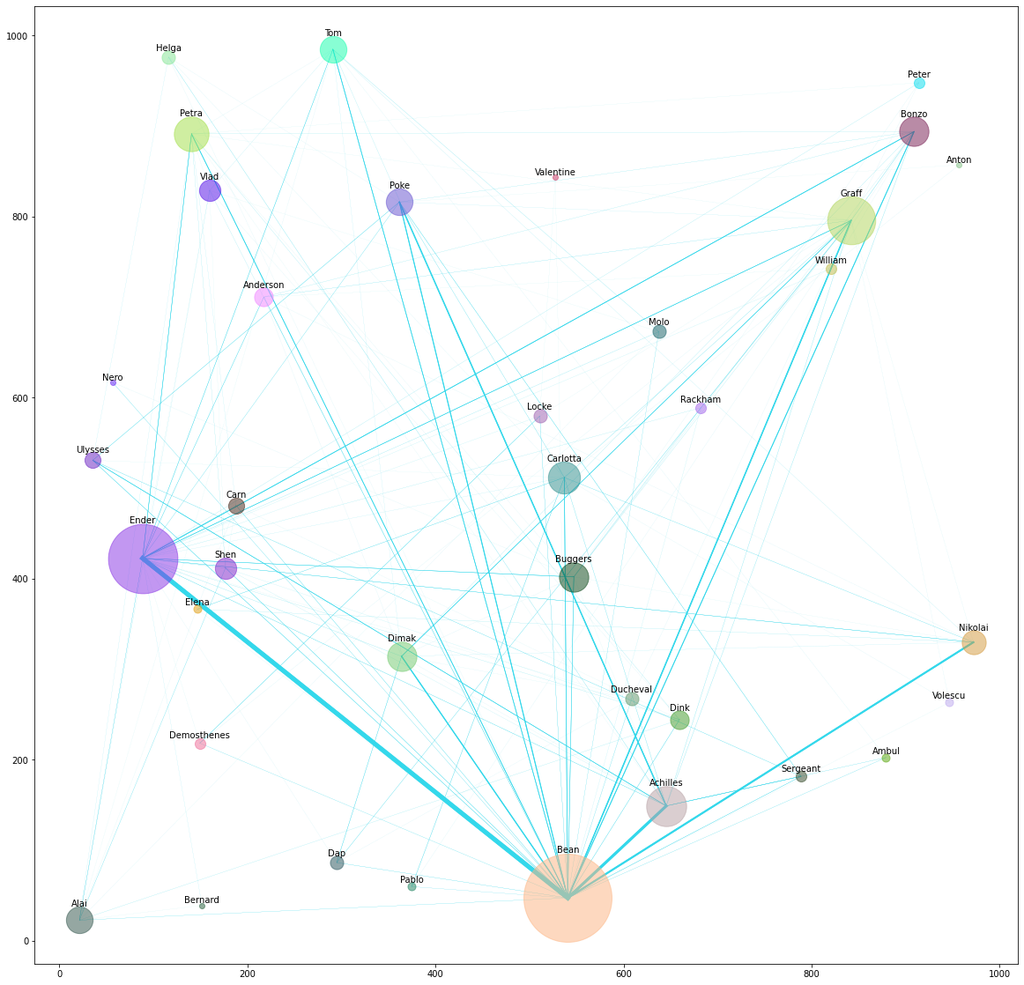

```python
#Creamos el renderizador de la red
worldWidth = 1000
worldHeight = 1000
networkRenderer = BookNetworkRenderer(network, worldWidth, worldHeight)
#Asignamos posiciones y colores a los nodos
networkRenderer.assignPositionsAndColors()
#Desplegamos el grafo (cruce de dedos)
networkRenderer.displayGraph()
```

### 3.- Calcular lo siguiente:

1. Tamaño y densidad
2. Longitud promedio de los caminos mas cortos
3. Excentricidad, diámetro y radio
4. Nodos con centralidad de grado, de intermediación y de cercanía y si esto coincide con alguna característica del personaje de la historia
5. Coeficiente de acumulación promedio de la red
6. Distribución de grado
7. Método Louvain para encontrar las comunidades en la red y dibujar los nodos de cada comunidad de un color distinto

#### 3.1.- Tamaño y densidad

```python
n,m,density = network.charactersGraph.getNetworkSizeAndDensity()
#Imprimimos el número de nodos
print("El número de nodos es: "+str(n))
#Imprimimos el número de conexiones
print("El número de conexiones es "+str(m))
#Imprimimos la densidad de la red
print("La densidad de la red es "+str(density))
```

```
El número de nodos es: 37
El número de conexiones es 296
La densidad de la red es 0.2222222222222222
```

#### 3.2.- Longitud promedio de caminos mas cortos ($L$)

```python
L = network.charactersGraph.getL()
print("La longitud promedio de los caminos más cortos entre nodos es "+str(L))
```

```
La longitud promedio de los caminos más cortos entre nodos es 1.8348348348347994
```

#### 3.3.- Excentricidades, diámetro y radio

```
El diámetro de la red es 3.0
El radio de la red es 2.0
```

```
<BarContainer object of 37 artists>
```

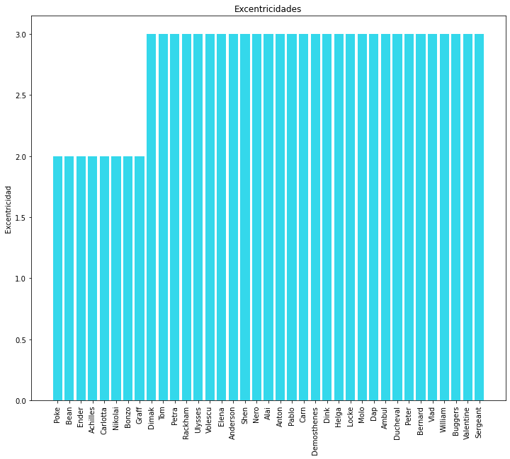

```python
excentricities, diameter, radius = network.charactersGraph.getExcentricity()
nodes = [i.nodeId for i in network.charactersGraph.nodes]

print("El diámetro de la red es "+str(diameter))
print("El radio de la red es "+str(radius))


plt.figure(figsize = (12,10))
plt.title("Excentricidades")
plt.ylabel("Excentricidad")
plt.xticks(range(0,len(nodes)),nodes, rotation='vertical')
plt.bar(nodes,excentricities, color = "#34d8eb")
```

#### 3.4.- Centralidad de grado, intermedia y de cercanía

```python
degreeCentrality, betweeness, closeness = network.charactersGraph.getCentralities()
```

```
Obteniendo centralidad de grado
Obteniendo centralidad de intermediación
Obteniendo centralidad de cercanía
```

```
<BarContainer object of 37 artists>
```

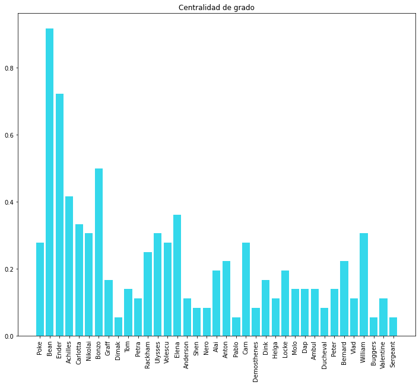

```python
plt.figure(figsize = (12,10))
plt.title("Centralidad de grado")
plt.xticks(range(0,len(nodes)),nodes, rotation='vertical')
plt.bar(nodes,degreeCentrality, color = "#34d8eb")
```

Como es de esperarse las centralidades de grado mas grandes las tienen tanto Bean como Ender, los personajes alrededor de los cuales gira la historia. Algo que me sorprendió es que la tercera centralidad mas grande la tiene Bonzo. Esto no lo había pensado, pero es verdad que el enfrentamiento entre Bonzo y Ender representa un suceso en el que convergen muchos personajes. En primer lugar todo el ejercito dragón es movilizado por Bean para intentar detener la pelea. Así también se involucran varios amigos de Ender como Petra o Shen. Finalmente, permitir que se desarrolle el enfrentamiento representa uno de las decisiones éticamente cuestionables del comandante Graff, y en varias ocasiones se le recrimina este hecho en el libro. Recuerdo incluso una conversación con Sor Carlotta donde se toca este tema.

```
<BarContainer object of 37 artists>
```

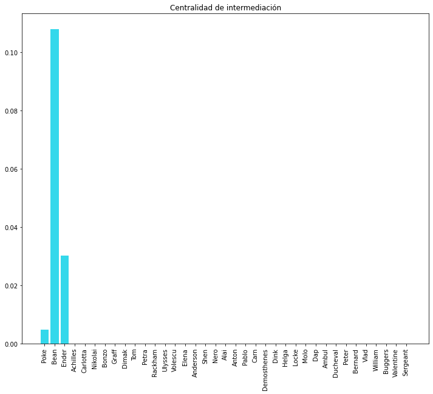

```python
plt.figure(figsize = (12,10))
plt.title("Centralidad de intermediación")
plt.xticks(range(0,len(nodes)),nodes, rotation='vertical')
plt.bar(nodes,betweeness, color = "#34d8eb")
```

Como se muestra en el gráfico anterior los personajes que presentan una mayor centralidad de intermediación son Bean, Ender y Poke. Esto a un nivel general tiene sentido, porque si lo pensamos hay 3 historias que van colindando entre sí: la de las calles de Rotterdam, los sucesos en la estación espacial vistos desde la perspectiva de Bean, y los mismos eventos vistos desde la perspectiva de Ender. En este caso el resultado nos dice que los mediadores importantes entre estos 3 contextos son Bean, Ender y Poke.

Me sorprendió un poco el caso de Poke, porque hubiese pensado que la mayor mediadora entre las calles de Rotterdam y los otros contextos debiese ser Sor Carlotta. Sin embargo, hay que considerar que muchas de estas interacciones, si no es que la mayoría suceden en los pensamientos de Bean, y definitivamente el personaje de las calles de Rotterdam que mas impacta a Bean es Poke. Esto es porque la "bondad" irracional de Poke, al acoger a Bean en su banda o confiar en Achilles representa un enigma para Bean, y uno de los patrones que mas se repiten a lo largo del libro es que cada vez que Bean no logra comprender algún aspecto de la conducta humana tiende a pensar en ella, así que definitivamente Poke representa un paso intermedio en muchos de los análisis de Bean.

```
<BarContainer object of 37 artists>
```

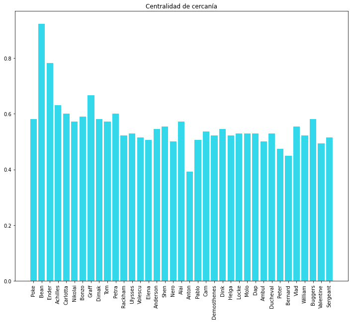

```python
plt.figure(figsize = (12,10))
plt.title("Centralidad de cercanía")
plt.xticks(range(0,len(nodes)),nodes, rotation='vertical')
plt.bar(nodes,closeness, color = "#34d8eb")
```

Este gráfico muestra cosas interesantes. Por supuesto los personajes mas cercanos a todos los demas siguen siendo tanto Ender, como Bean, sin embargo aquí encontramos que la tercera persona mas cercana a todos es el comandante Graff.

Graff, es el comandante a cargo de la estación espacial y su trabajo es principalmente de coordinación, el se encarga tanto de tutorear, como de manipular en ciertos casos el paso de Ender en la escuela de Batalla. A su vez mantiene comunicación constante con sus oficiales para estar al tanto de las acciones de Bean, y con Sor Carlotta para tener toda la información relevante que ella averigua. Sin duda es de los personajes mas comunicadas y con mas responsabilidades de la historia (en algún momento su estrés por tratar de controlar todo llega a ser tan alto que comienza a engordar). Por ello tiene sentido que Graff tenga una centralidad de cercania grande.

#### 3.5.- Coeficiente de acumulación ($C$)

```
El coeficiente promedio de acumulación es 0.5768793770976268
```

```
<BarContainer object of 37 artists>
```

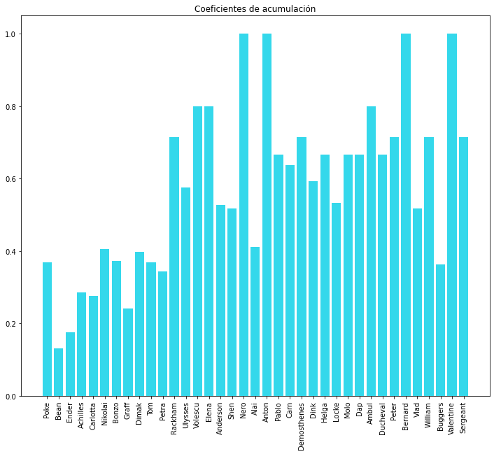

```python
meanClustering, clusteringCoefficients = network.charactersGraph.getAverageClusteringCoefficient()
print("El coeficiente promedio de acumulación es "+str(meanClustering))
plt.figure(figsize = (12,10))
plt.title("Coeficientes de acumulación")
plt.xticks(range(0,len(nodes)),nodes, rotation='vertical')
plt.bar(nodes,clusteringCoefficients, color = "#34d8eb")
```

El gráfico anterior muestra que la mayor acumulación la presentan personajes un tanto secundarios como Valentine, Nero etc. Sospecho que lo que está sucediendo es un caso donde su vecindario tiene muy pocos elementos pero todos ellos se encuentran conectados entre sí lo cual resulta en un valor grande para $C$. La verdad es que quizás estoy cometiendo algún error al interpretar la medida, debo investigar mas sobre ella.

#### 3.6. Distribución de grado

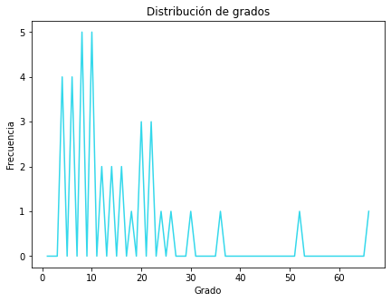

```python
networkRenderer.plotDegreeDistribution()
```

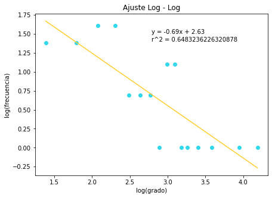

```python
networkRenderer.plotLogLogDegreeDistribution()
```

La grafica log - log de la distribución de grados muestra que esta se ajusta medianamente bien a una ley de potencias de tipo $f = cx^{r}$, donde r sería igual a -0.69. No me atrevería sin embargo a aseverar que la red es libre de escala, porque la $r^2$ no es muy alta, y me parece que no pasaría una prueba de hipótesis si la hicieramos.

Como una especie de especulación, presiento que si se analizara además la historia paralela, que es el juego de Ender, esta relación de potencias en la distribución de grados podría quedar mejor dilucidada.

#### 3.6.- Algoritmo de Louvain para encontrar comunidades

```
221
```

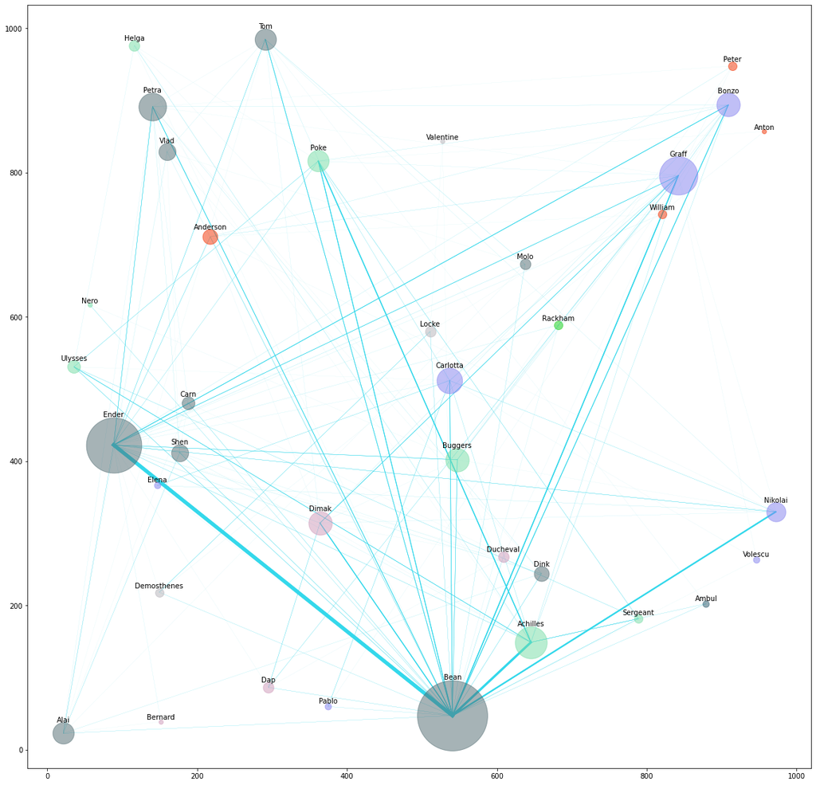

```python
networkRenderer.drawCommunities()
```

La separación en comunidades resulta lógica en varios casos. Podemos identificar:

- En gris oscuro, el jeesh de Ender, que combate con él en la tercera guerra fórmica (véase 0.4), este es conformado por Ender, Bean, Petra, Alai, Shen, Carn Carby, Fly Molo, Crazy Tom, Dink Meeker y Vlad
- En verde claro, personas de las calles de Rotterdam que juegan un papel en la historia de Bean, esta incluye a Helga (dueña del comedor comunitario), Seargent, Poke, Ulysses y Achilles (vease la sección 0.1), hay un mismatch, que es Nero, el cual es un niño que se confronta con Ender en sus primeros dias en la escuela de batalla.
- En Morado la red de investigación de Sor Carlotta. Me parece que no lo mencioné pero ella mantenía comunicación constante con Graff, el director de la escuela de batalla y tutor de Ender. Como se dijo en la sección 0.3 al investigar la historia de Bean ella establece vinculos con Pablo de Noches, Volescu, Elena (la madre de Bean) y Nikolai. Bonzo aquí es un mismatch, pero probablemente fue asociado por la conexión que tenía este con Graff, en el sentido de que Graff utiliza la confrontación entre Bonzo y Ender como una lección para este último.
- En gris claro: la comunidad de escritores geopolíticos influyentes: Demosthenes y Locke (vease sección 0.3), que en realidad son los hermanos de Ender: Valentine, quien también es incluida en esta comunidad y Peter que por alguna razón no fue incluido en esta. En cierta forma esto tiene sentido, ya que Ender no se llevaba muy bien con Peter, por lo cual es posible que Bean no haya obtenido mucha información sobre el en la estación espacial, la verdad no recuerdo.
- En rosa otros oficiales de la flota internacional como Dap o Dimak
- Naranja me parece que podría ser una comunidad de personajes que no tienen conexiones fuertes con otras comunidades o algo así, porque no guardan mucha relación entre ellos.